# Tensorflow_Sentiment_Analysis

```python
# setup for multiple outputs from single cell
from IPython.core.interactiveshell import InteractiveShell
InteractiveShell.ast_node_interactivity = 'all'
```

```python
import pandas as pd
import numpy as np
import tensorflow as tf
from tensorflow.keras.preprocessing.text import Tokenizer
from tensorflow.keras.preprocessing.sequence import pad_sequences
from sklearn.model_selection import train_test_split, KFold
import re
from collections import Counter
import matplotlib.pyplot as plt
import nltk
from nltk.corpus import stopwords
from nltk.tokenize import word_tokenize
from wordcloud import WordCloud
import spacy
from sklearn.metrics import confusion_matrix
import seaborn as sns
```

```
2024-04-01 01:08:52.588043: I tensorflow/core/platform/cpu_feature_guard.cc:182] This TensorFlow binary is optimized to use available CPU instructions in performance-critical operations.
To enable the following instructions: SSE4.1 SSE4.2 AVX, in other operations, rebuild TensorFlow with the appropriate compiler flags.
```

```python
###########################################################################################
# IMPORT CSV FILE TO DATA FRAME ###########################################################
###########################################################################################


# NOTE: Before importing the csv to a data fame, it was helpful to open the csv in excel and
# covnvert all data to a single font and font size. This made it easier to remove all punctuations
# by assuring that they are all of the same font

# Load the dataset from CSV file into a DataFrame
df_original_reviews = pd.read_csv('IMDB_Dataset.csv')
# Display the DataFrame
df_original_reviews
```

|  | review | sentiment |
| --- | --- | --- |
| 0 | One of the other reviewers has mentioned that ... | positive |
| 1 | A wonderful little production. <br /><br />The... | positive |
| 2 | I thought this was a wonderful way to spend ti... | positive |
| 3 | Basically there's a family where a little boy ... | negative |
| 4 | Petter Mattei's "Love in the Time of Money" is... | positive |
| ... | ... | ... |
| 49995 | I thought this movie did a down right good job... | positive |
| 49996 | Bad plot, bad dialogue, bad acting, idiotic di... | negative |
| 49997 | I am a Catholic taught in parochial elementary... | negative |
| 49998 | I'm going to have to disagree with the previou... | negative |
| 49999 | No one expects the Star Trek movies to be high... | negative |

50000 rows × 2 columns

```python
######################=============== DATA CLEANING =====================##################

###########################################################################################
# FORMAT DATA FRAME #######################################################################
###########################################################################################

# Convert sentiments from positive/negative to 1/0
# Define a dictionary mapping string labels to integer values
label_map = {'positive': 1, 'negative': 0}
# Convert the last column to integer values based on the mapping
df_original_reviews['sentiment'] = df_original_reviews['sentiment'].map(label_map)
# Display the updated DataFrame
df_original_reviews
```

|  | review | sentiment |
| --- | --- | --- |
| 0 | One of the other reviewers has mentioned that ... | 1 |
| 1 | A wonderful little production. <br /><br />The... | 1 |
| 2 | I thought this was a wonderful way to spend ti... | 1 |
| 3 | Basically there's a family where a little boy ... | 0 |
| 4 | Petter Mattei's "Love in the Time of Money" is... | 1 |
| ... | ... | ... |
| 49995 | I thought this movie did a down right good job... | 1 |
| 49996 | Bad plot, bad dialogue, bad acting, idiotic di... | 0 |
| 49997 | I am a Catholic taught in parochial elementary... | 0 |
| 49998 | I'm going to have to disagree with the previou... | 0 |
| 49999 | No one expects the Star Trek movies to be high... | 0 |

50000 rows × 2 columns

```python
# Label index and reset index to begin at 1
# Rename index and start index at value of 1
df_original_reviews.index = range(1, len(df_original_reviews) + 1)
df_original_reviews.index.name = 'index'
# Display the updated DataFrame
df_original_reviews
```

| index | review | sentiment |
| --- | --- | --- |
| 1 | One of the other reviewers has mentioned that ... | 1 |
| 2 | A wonderful little production. <br /><br />The... | 1 |
| 3 | I thought this was a wonderful way to spend ti... | 1 |
| 4 | Basically there's a family where a little boy ... | 0 |
| 5 | Petter Mattei's "Love in the Time of Money" is... | 1 |
| ... | ... | ... |
| 49996 | I thought this movie did a down right good job... | 1 |
| 49997 | Bad plot, bad dialogue, bad acting, idiotic di... | 0 |
| 49998 | I am a Catholic taught in parochial elementary... | 0 |
| 49999 | I'm going to have to disagree with the previou... | 0 |
| 50000 | No one expects the Star Trek movies to be high... | 0 |

50000 rows × 2 columns

```python
# Capture original text reviews for latter display after classification and confusion matrix
# Split the dataset into texts and labels
texts_original = df_original_reviews['review'].values
labels_original = df_original_reviews['sentiment'].values
df_all_reviews = df_original_reviews
```

```python
###########################################################################################
# REMOVE STOP WORDS AND UNWANTED CHARACTERS ###############################################
###########################################################################################

# Remove unwanted HTML strings, "<br /><br />", and other unwanted characters
unwanted_HTML_string = ['<br /><br />',
                        '...', ':', '?', '.', ';',
                        '!', ')','(','"', "'s",
                       '-', '*', "'","n't", ',']
# Create a regex pattern to match any unwanted string
unwanted_pattern = '|'.join(map(re.escape, unwanted_HTML_string))
# Iterate over each row in the specified column and remove unwanted HTML characters/strings
for index, row in df_all_reviews.iterrows():
    unclean_string = row['review']  # Extract text from the specified column

    # Remove unwanted characters/strings using regular expressions
    clean_string = re.sub(unwanted_pattern, '', unclean_string)

    # Update the DataFrame with the cleaned text
    df_all_reviews.at[index, 'review'] = clean_string

# Display the updated DataFrame
df_all_reviews.head(5)
df_all_reviews.tail(5)
```

| index | review | sentiment |
| --- | --- | --- |
| 1 | One of the other reviewers has mentioned that ... | 1 |
| 2 | A wonderful little production The filming tech... | 1 |
| 3 | I thought this was a wonderful way to spend ti... | 1 |
| 4 | Basically there a family where a little boy Ja... | 0 |
| 5 | Petter Mattei Love in the Time of Money is a v... | 1 |

| index | review | sentiment |
| --- | --- | --- |
| 49996 | I thought this movie did a down right good job... | 1 |
| 49997 | Bad plot bad dialogue bad acting idiotic direc... | 0 |
| 49998 | I am a Catholic taught in parochial elementary... | 0 |
| 49999 | Im going to have to disagree with the previous... | 0 |
| 50000 | No one expects the Star Trek movies to be high... | 0 |

```python
# Remove stop words
# Get the English stopwords
stop_words = set(stopwords.words('english'))

# Iterate over each row in the specified column and remove stopwords
for index, row in df_all_reviews.iterrows():
    text = row['review']  # Extract text from the specified column

    # Tokenize the text into words
    words = nltk.word_tokenize(text)

    # Remove stopwords from the tokenized words
    filtered_words = [word for word in words if word.lower() not in stop_words]

    # Join the filtered words back into a single string and update the DataFrame
    df_all_reviews.at[index, 'review'] = ' '.join(filtered_words)

# Display the updated DataFrame
df_all_reviews.head(5)
df_all_reviews.tail(5)
```

| index | review | sentiment |
| --- | --- | --- |
| 1 | One reviewers mentioned watching 1 Oz episode ... | 1 |
| 2 | wonderful little production filming technique ... | 1 |
| 3 | thought wonderful way spend time hot summer we... | 1 |
| 4 | Basically family little boy Jake thinks zombie... | 0 |
| 5 | Petter Mattei Love Time Money visually stunnin... | 1 |

| index | review | sentiment |
| --- | --- | --- |
| 49996 | thought movie right good job creative original... | 1 |
| 49997 | Bad plot bad dialogue bad acting idiotic direc... | 0 |
| 49998 | Catholic taught parochial elementary schools n... | 0 |
| 49999 | Im going disagree previous comment side Maltin... | 0 |
| 50000 | one expects Star Trek movies high art fans exp... | 0 |

```python
###########################################################################################
# BREAK MAIN DATA FRAME INTO POSITIVE AND NEGATIVE REWIEWS ################################
###########################################################################################

# Select negative review strings
df_negative_reviews = df_all_reviews[df_all_reviews['sentiment'] == 0]
print(len(df_negative_reviews))
```

```
25000
```

```python
# Select positive review strings
df_positive_reviews = df_all_reviews[df_all_reviews['sentiment'] == 1]
print(len(df_positive_reviews))
```

```
25000
```

```python
##############===============EXPLORATORY DATA ANALYSIS =====================###############

###########################################################################################
# DISPLAY BAR CHARTS SHOWING TOP 25 WORDS FOR POSITIVE AND NEGATIVE REWIEWS ###############
###########################################################################################

# A function to display top 25 words in horizontal bar chart
def top_25_bar(target_dataframe, sentiment, word_type):
    # extract strings in review column of dataframe
    strings = target_dataframe['review']

    # Join all strings in the column into a single string
    all_joined_strings = ' '.join(strings)

    # Split the text into words and count the frequency of each word
    word_counts = Counter(all_joined_strings.split())

    # Get the top 25 most common words
    top_words = dict(word_counts.most_common(25))

    # Create a horizontal bar chart
    plt.figure(figsize=(10, 8))
    plt.barh(list(top_words.keys()), list(top_words.values()), color='skyblue')
    plt.xlabel('Frequency')
    plt.ylabel('Word')
    title = 'Top 25 ' + str(sentiment) + ' ' + str(word_type) + ' in ' + str(sentiment) + ' reviews'
    plt.title(title)
    plt.gca().invert_yaxis()  # Invert y-axis to have the most frequent word at the top
    plt.show();

    return top_words, title
```

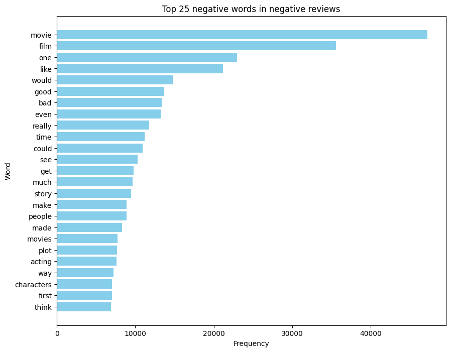

```
FIGURE  1 (above):  Top 25 negative words in negative reviews
```

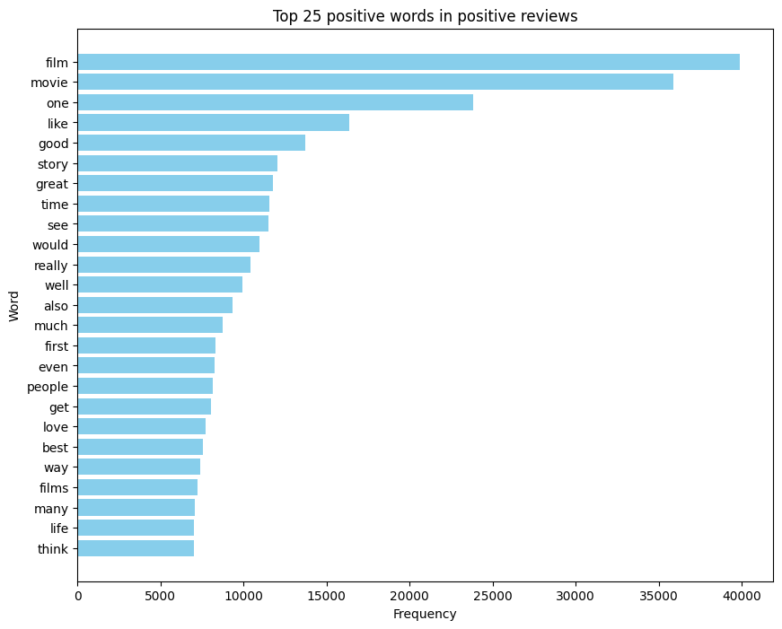

```
FIGURE  2 (above):  Top 25 positive words in positive reviews
```

```python
# Top 25 words in negative reviews
top_25_negative_all_words, title = top_25_bar(df_negative_reviews, 'negative', 'words')
count = 1
print("FIGURE ", count, "(above): ", title)
# Top 25 words in positive reviews
top_25_positive_all_words, title = top_25_bar(df_positive_reviews, 'positive', 'words')
count += 1
print("FIGURE ", count, "(above): ", title)
```

```python
###########################################################################################
# DISPLAY WORD CLOUDS SHOWING TOP 25 WORDS FOR POSITIVE AND NEGATIVE REWIEWS ##############
###########################################################################################

# A function to display top 25 words in word cloud
def top_25_wordcloud(target_dataframe, sentiment, word_type):
    # extract strings in review column of dataframe
    all_joined_strings = ' '.join(target_dataframe['review'])

    # Word cloud of top 100 words in all negative reviews
    word_cloud_parameters ={'width':800, 'height':400,
                            'background_color':'white',
                            'colormap':'viridis',
                            'max_words':100
                           }
    # Construct word cloud
    wordcloud = WordCloud(**word_cloud_parameters).generate(all_joined_strings)
    # Plot the word cloud
    plt.figure(figsize=(10, 5))
    plt.imshow(wordcloud, interpolation='bilinear')
    title = 'TOP 25 ' + str(sentiment) + ' ' + str(word_type) + ' IN ' + str(sentiment) + ' REVIEWS'
    plt.title(title)
    plt.axis('off')
    plt.tight_layout()
    plt.show();

    return title
```

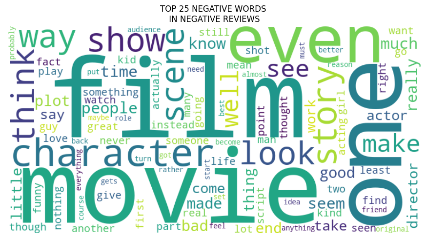

[output not shown]

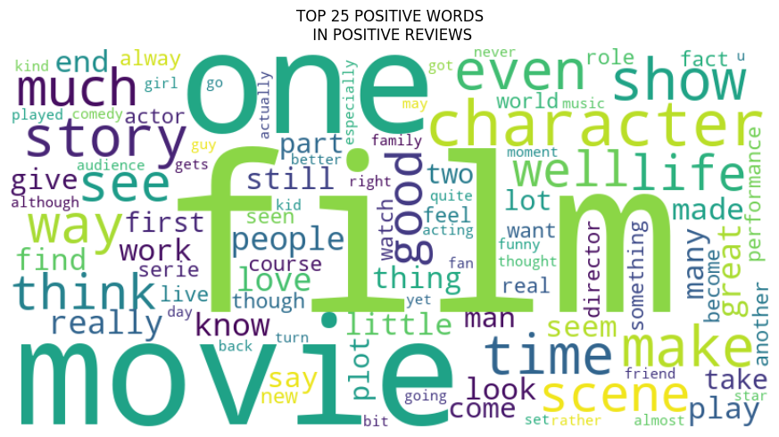

[output not shown]

```python
# Top 25 words word cloud in negative reviews
title = top_25_wordcloud(df_negative_reviews, 'NEGATIVE', 'WORDS\n')
count += 1
print("FIGURE ", count, "(above): ", title)
# Top 25 words word cloud in positive reviews
title =  top_25_wordcloud(df_positive_reviews, 'POSITIVE', 'WORDS\n')
count += 1
print("FIGURE ", count, "(above): ", title)
```

```python
###########################################################################################
# INSTALL SPACY FOR ADJECTIVE AND VERB DETECTION IN POSITIVE AND NEGATIVE REWIEWS #########
###########################################################################################

# Extract 25 most common positive and negative adjectives in reviews
# May need to install spacy for next steps
!pip install spacy
```

```python
!python -m spacy download en_core_web_sm
```

```
     ━━━━━━━━━━━━━━━━━━━━━━━━━━━━━━━━━━━━━━━━ 12.8/12.8 MB 2.7 MB/s eta 0:00:00m eta 0:00:01[36m0:00:01

✔ Download and installation successful
You can now load the package via spacy.load('en_core_web_sm')
```

```python
###########################################################################################
# FIND ADJECTIVES IN POSITIVE AND NEGATIVE REWIEWS ########################################
###########################################################################################

# A function to extract ADJECTIVES in a group of sentiment reviews
def review_adjectives(target_dataframe):
    # Load spaCy English language model
    nlp = spacy.load("en_core_web_sm")

    # Iterate over each row in the specified column isolate adjectives
    for index, row in target_dataframe.iterrows():
        # Extract original individual string from the review column
        text = row['review']

        # Process the string with spaCy
        doc = nlp(text)

        # Extract adjectives from the string
        adjectives = [] # Define/reset empty array to hold extracted adjectives
        adjectives = [token.text for token in doc if token.pos_ == "ADJ"]

        # Join the adjectives back into a single adjective string
        # Insert adjective string into the DataFrame to replace original string
        target_dataframe.at[index, 'review'] = ' '.join(adjectives)

    return target_dataframe
```

```python
# Extract adjectives from negative reviews
negative_adjectives = review_adjectives(df_negative_reviews)
```

```python
negative_adjectives.head(5)
negative_adjectives.tail(5)
```

| index | review | sentiment |
| --- | --- | --- |
| 4 | little slower watchable real similar meaningless | 0 |
| 8 | amazing fresh innovative brilliant funny compl... | 0 |
| 9 | positive Bad awful less cheap nasty boring hap... | 0 |
| 11 | quirky oddness actual odd funny oddness funny ... | 0 |
| 12 | scariest big right young tired beautiful happy... | 0 |

| index | review | sentiment |
| --- | --- | --- |
| 49995 | typical genuine memorable clever bad ugly bori... | 0 |
| 49997 | Bad bad bad idiotic annoying crappy bad better... | 0 |
| 49998 | Catholic parochial elementary high good Cathol... | 0 |
| 49999 | disagree previous second vicious Western centr... | 0 |
| 50000 | high good best implausible worst far goofy wor... | 0 |

```python
# Extract adjectives from positive reviews
positive_adjectives = review_adjectives(df_positive_reviews)
```

```python
positive_adjectives.head(5)
positive_adjectives.tail(5)
```

| index | review | sentiment |
| --- | --- | --- |
| 1 | first right hearted timid classic experimental... | 1 |
| 2 | wonderful little entire seamless worth masterf... | 1 |
| 3 | wonderful hot lighthearted simplistic witty li... | 1 |
| 5 | stunning vivid different present different nex... | 1 |
| 6 | favorite noble preachy old last sympathetic de... | 1 |

| index | review | sentiment |
| --- | --- | --- |
| 49984 | original back whole new excellent special supe... | 1 |
| 49986 | best complete utter whole perfect much younger... | 1 |
| 49990 | modern true favorite Jewish top pure superfici... | 1 |
| 49993 | live stereotypical sure complex great present ... | 1 |
| 49996 | good creative original first whole last underr... | 1 |

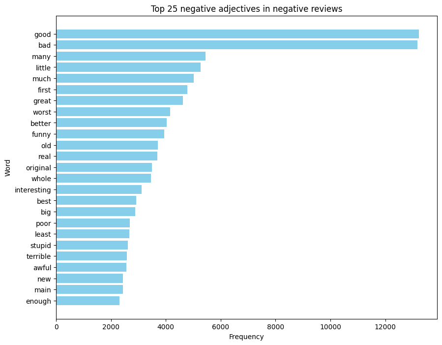

```
FIGURE  5 (above):  Top 25 negative adjectives in negative reviews
```

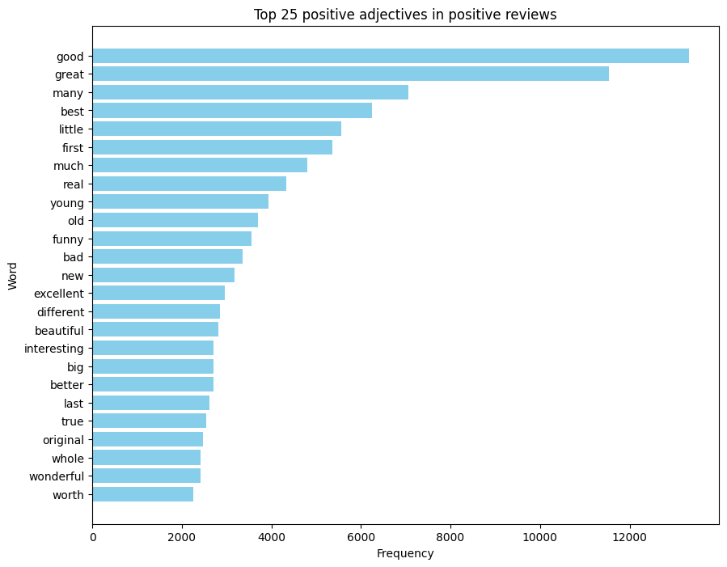

```
FIGURE  6 (above):  Top 25 positive adjectives in positive reviews
```

```python
###########################################################################################
# DISPLAY BAR CHARTS SHOWING TOP 25 ADJECTIVES FOR POSITIVE AND NEGATIVE REWIEWS ##########
###########################################################################################

# Top 25 adjectives in negative reviews
top_25_negative_adjective_words, title = top_25_bar(negative_adjectives, 'negative', 'adjectives')
count += 1
print("FIGURE ", count, "(above): ", title)
# Top 25 adjectives in positive reviews
top_25_positive_adjective_words, title = top_25_bar(positive_adjectives, 'positive', 'adjectives')
count += 1
print("FIGURE ", count, "(above): ", title)
```

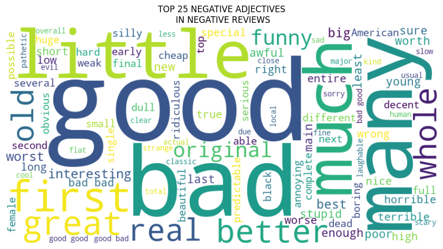

[output not shown]

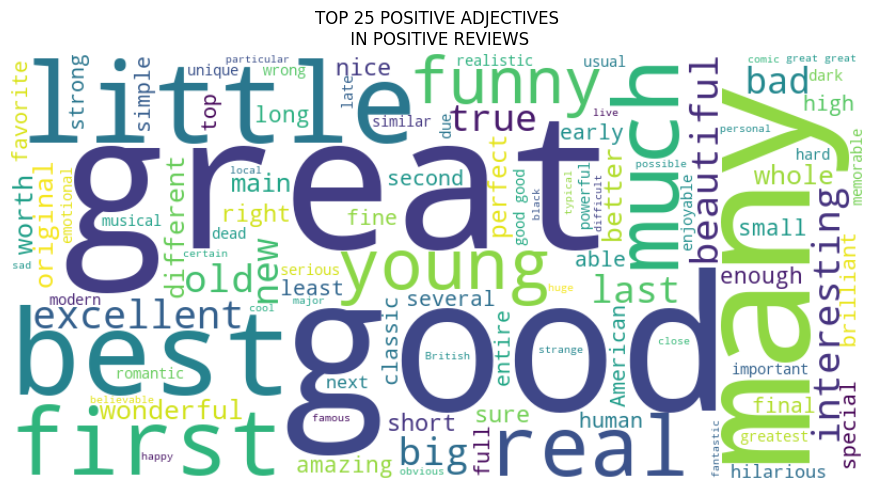

[output not shown]

```python
###########################################################################################
# DISPLAY WORD CLOUDS SHOWING TOP 25 ADJECTIVES FOR POSITIVE AND NEGATIVE REWIEWS #########
###########################################################################################

# Top 25 adjectives word cloud in negative reviews
title = top_25_wordcloud(negative_adjectives, 'NEGATIVE', 'ADJECTIVES\n')
count += 1
print("FIGURE ", count, "(above): ", title)
# Top 25 adjectives word cloud in positive reviews
title = top_25_wordcloud(positive_adjectives, 'POSITIVE', 'ADJECTIVES\n')
count += 1
print("FIGURE ", count, "(above): ", title)
```

Observations:  
-- The adjectives 'good' and 'bad' appear at nearly equal word rank in negative reviews (figures 5 and 7).  
-- The adjective 'good' appears without the word 'bad' much more often in positive reviews (figure 6).  
-- The adjectives 'good', 'great', 'many', and 'best' appear more often in positive reviews than in negative reviews (figure 8).

```python
###########################################################################################
# FIND VERBS IN POSITIVE AND NEGATIVE REWIEWS #############################################
###########################################################################################

# A function to extract VERBS in a group of sentiment reviews
def review_verbs(target_dataframe):
    # Load spaCy English language model
    nlp = spacy.load("en_core_web_sm")

    # Iterate over each row in the specified column isolate verbss
    for index, row in target_dataframe.iterrows():
        # Extract original individual string from the review column
        text = row['review']

        # Process the string with spaCy
        doc = nlp(text)

        # Extract verbss from the string
        verbs = [] # Define/reset empty array to hold extracted verbs
        verbs = [token.text for token in doc if token.pos_ == "VERB"]

        # Join the verbs back into a single verb string
        # Insert verb string into the DataFrame to replace original string
        target_dataframe.at[index, 'review'] = ' '.join(verbs)

    return target_dataframe
```

```python
# Extract verbs from negative reviews
negative_verbs = review_verbs(df_negative_reviews)
negative_verbs.head(5)
negative_verbs.tail(5)
```

| index | review | sentiment |
| --- | --- | --- |
| 4 |  | 0 |
| 8 | fallen entertaining | 0 |
| 9 |  | 0 |
| 11 |  | 0 |
| 12 |  | 0 |

| index | review | sentiment |
| --- | --- | --- |
| 49995 | boring | 0 |
| 49997 |  | 0 |
| 49998 | organized | 0 |
| 49999 | disagree mumbling | 0 |
| 50000 |  | 0 |

```python
# Extract verbs from positive reviews
positive_verbs = review_verbs(df_positive_reviews)
positive_verbs.head(5)
positive_verbs.tail(5)
```

| index | review | sentiment |
| --- | --- | --- |
| 1 |  | 1 |
| 2 |  | 1 |
| 3 |  | 1 |
| 5 |  | 1 |
| 6 |  | 1 |

| index | review | sentiment |
| --- | --- | --- |
| 49984 |  | 1 |
| 49986 |  | 1 |
| 49990 |  | 1 |
| 49993 | live | 1 |
| 49996 |  | 1 |

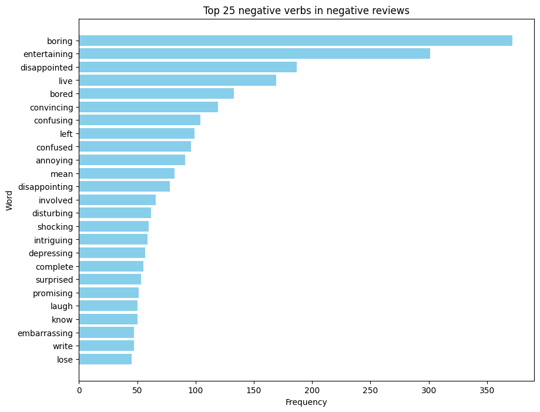

```
FIGURE  9 (above):  Top 25 negative verbs in negative reviews
```

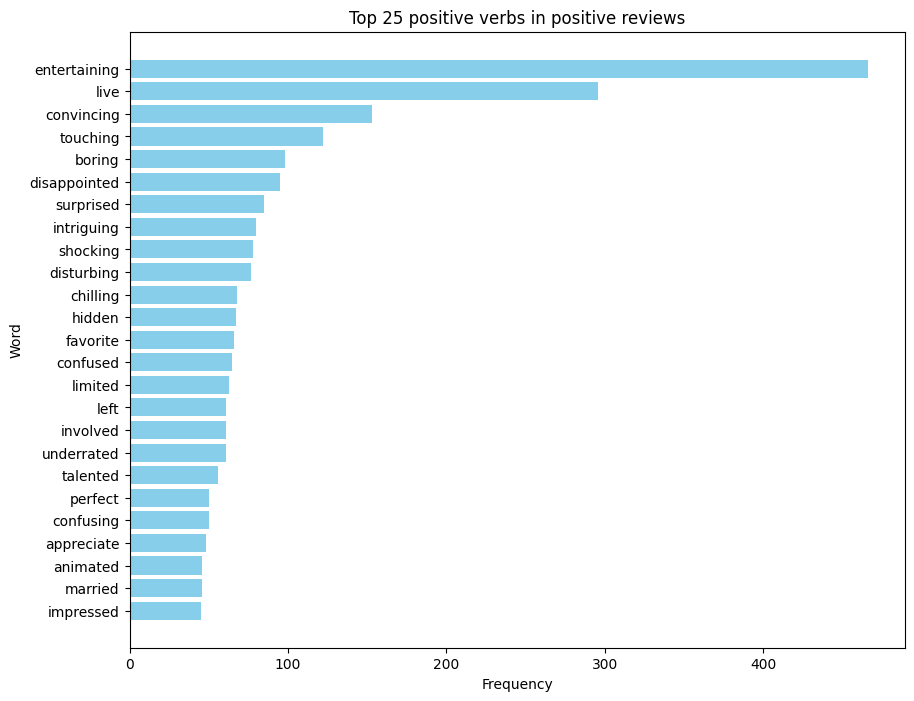

```
FIGURE  10 (above):  Top 25 positive verbs in positive reviews
```

```python
###########################################################################################
# DISPLAY BAR CHARTS SHOWING TOP 25 VERBS FOR POSITIVE AND NEGATIVE REWIEWS ###############
###########################################################################################

# Top 25 verbs in negative reviews
top_25_negative_verb_words, title = top_25_bar(negative_verbs, 'negative', 'verbs')
count += 1
print("FIGURE ", count, "(above): ", title)
# Top 25 verbs in positive reviews
top_25_positive_verb_words, title = top_25_bar(positive_verbs, 'positive', 'verbs')
count += 1
print("FIGURE ", count, "(above): ", title)
```

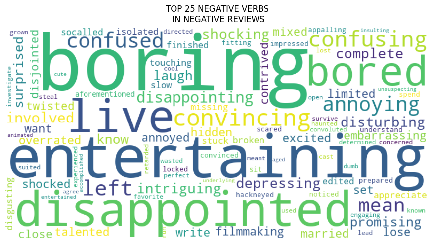

[output not shown]

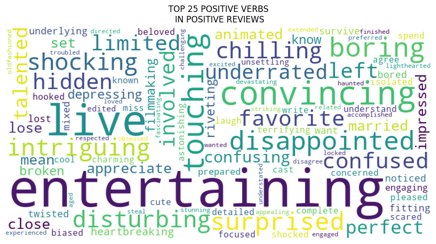

[output not shown]

```python
###########################################################################################
# DISPLAY WORD CLOUDS SHOWING TOP 25 VERBS FOR POSITIVE AND NEGATIVE REWIEWS ##############
###########################################################################################

# Top 25 verbs word cloud in negative reviews
title = top_25_wordcloud(negative_verbs, 'NEGATIVE', 'VERBS\n')
count += 1
print("FIGURE ", count, "(above): ", title)
# Top 25 verbs word cloud in positive reviews
title = top_25_wordcloud(positive_verbs, 'POSITIVE', 'VERBS\n')
count += 1
print("FIGURE ", count, "(above): ", title)
```

Observations:  
-- In negative reviews the verbs 'boring', 'disappointed', and 'bored' ranked high (figures 9 and 11).  
-- In positive reviews the verbs 'convincing' and 'touching' ranked high (figures 10 and 12).  
-- Surprisingly, some verbs appeared in both positive and negative reviews : 'confused/confusing', 'disappointed' and 'boring' (figures 9 and 10).  
-- Based upon the word clouds (figures 11 and 12), it seems both positive and negative reviewers found the movies they watched 'entertaining'. Negative reviewers were more 'bored' and 'disappointed'. Specifically, they may have been 'bored' and 'disappoined' with the 'characters', 'acting' and 'story' as shown in the top 25 general word bar graphs (figure 1).

```python
###################=============== CLASSIFICATION =====================####################

###########################################################################################
################### TRY CLASSIFICATION **WITHOUT** CROSSFOLD VALIDATION ###################
###########################################################################################

# Split the dataset into texts and labels
texts = df_all_reviews['review'].values
labels = df_all_reviews['sentiment'].values

# Tokenize the text data by converting each word into a vocabulary index number

# Define maximum number of unique words to be considered in the tokenization process
#    based upon word frequency (the vocabulary)
max_words = 10000
# Instance of tokenizer class
# oov_token="<OOV>" defines a token to be used for out-of-vocabulary (OOV) words
tokenizer = Tokenizer(num_words=max_words, oov_token="<OOV>")
# Acquire the 10000 words in the vocabulary by analyzing each line of text.
# Each word is assigned an integer index in the vocabulary
tokenizer.fit_on_texts(texts)
# Replace each word in the text with its corresponding integer index in the
#   vocabulary. Words that are not present in the vocabulary are replaced with
#   the OOV token specified earlier
sequences = tokenizer.texts_to_sequences(texts)

# Pad sequences to ensure uniform length

# Define maximum number of tokens (or words) that each sequence should contain after padding or truncation.
max_length = 100
# Each sequence is a list of integers, with each integer corresponding to a word index in the vocabulary.
# Sequences are padded or truncated at their ends or "post" to max length of 100
padded_sequences = pad_sequences(sequences, maxlen=max_length, padding='post', truncating='post')

# Split the data into training and test sets
# Test/Train data sets ratio is 50/50
train_texts, test_texts, train_labels, test_labels = train_test_split(padded_sequences, labels, test_size=0.5, random_state=42)
```

```python
# Define the model architecture
model = tf.keras.Sequential([
    # "input_dim" -- the maximum integer index that can be expected in input data
    # "output_dim" -- determines the dimensionality of the embedding space.
    #    Represent each word as a dense vector of length output_dim
    # "input_length" -- specifies the length of input sequences.
    # This dense layer captures word semantics or in text context word meanings
    tf.keras.layers.Embedding(input_dim=max_words, output_dim=16, input_length=max_length),
    # This layer averages the feature values across all time steps in each sequence
    #   into a shorter sequence for faster processing
    tf.keras.layers.GlobalAveragePooling1D(),
    # The sigmoid activation function compresses outputs of the previous layer between
    #   1 and 0, expressed as probabilities for binary classification.
    tf.keras.layers.Dense(1, activation='sigmoid')
])

# Compile the model with loss function, chosen optimizer, and accuracy metric
model.compile(loss='binary_crossentropy', optimizer='adam', metrics=['accuracy'])
```

```
2024-04-01 01:37:19.450053: I tensorflow/core/common_runtime/process_util.cc:146] Creating new thread pool with default inter op setting: 2. Tune using inter_op_parallelism_threads for best performance.
```

```python
# Train the model
model.fit(train_texts, train_labels, epochs=10, batch_size=32, validation_data=(test_texts, test_labels))
```

```
<keras.callbacks.History at 0x7f96324466b0>
```

```python
# Evaluate the model on test set
test_loss, test_accuracy = model.evaluate(test_texts, test_labels)
print("Test Loss:", test_loss)
print("Test Accuracy:", test_accuracy)
```

```
Test Loss: 0.32805135846138
Test Accuracy: 0.8678399920463562
```

```python
###########################################################################################
################### TRY CLASSIFICATION **WITH** CROSSFOLD VALIDATION ######################
###########################################################################################

# Split the dataset into texts and labels
texts = df_all_reviews['review'].values
labels = df_all_reviews['sentiment'].values

# Tokenize the text data
max_words = 10000
tokenizer = Tokenizer(num_words=max_words, oov_token="<OOV>")
tokenizer.fit_on_texts(texts)
sequences = tokenizer.texts_to_sequences(texts)

# Pad sequences to ensure uniform length
max_length = 100
padded_sequences = pad_sequences(sequences, maxlen=max_length, padding='post', truncating='post')

# Define the model architecture
model = tf.keras.Sequential([
    tf.keras.layers.Embedding(input_dim=max_words, output_dim=16, input_length=max_length),
    tf.keras.layers.GlobalAveragePooling1D(),
    tf.keras.layers.Dense(1, activation='sigmoid')
])

# Compile the model
model.compile(loss='binary_crossentropy', optimizer='adam', metrics=['accuracy'])

# Define number of folds for cross-validation
# This breaks the train and test data sets into 5 "folds" or sections
num_folds = 5

# Perform cross-validation
# Split train data sets and test data sets into 5 folds each
kf = KFold(n_splits=num_folds, shuffle=True)
# Define an empty array to hold accuracy of each test fold-train fold pair
fold_accuracy = []

for train_index, test_index in kf.split(padded_sequences):
    # Select a train data set fold or section
    train_texts_fold = padded_sequences[train_index]
    train_labels_fold = labels[train_index]
    # Select a test data set fold or section
    test_texts_fold = padded_sequences[test_index]
    test_labels_fold = labels[test_index]

    # Train the model on this test fold-train fold pair
    model.fit(train_texts_fold, train_labels_fold, epochs=10, batch_size=32)

    # Evaluate accuracy on this test fold-train fold pair
    _, accuracy = model.evaluate(test_texts_fold, test_labels_fold)
    fold_accuracy.append(accuracy)

# Compute mean accuracy across all test fold-train fold pairings
mean_accuracy = np.mean(fold_accuracy)
print("Mean Cross-Validation Accuracy:", mean_accuracy)
```

```
<keras.callbacks.History at 0x7f962cb4e3b0>
```

```
<keras.callbacks.History at 0x7f96296506a0>
```

```
<keras.callbacks.History at 0x7f9626a33640>
```

```
<keras.callbacks.History at 0x7f962a8bb760>
```

```
<keras.callbacks.History at 0x7f962ca7f070>
```

```
Mean Cross-Validation Accuracy: 0.8872399926185608
```

```python
# Evaluate the cross validation trained model on test set
test_loss, test_accuracy = model.evaluate(test_texts, test_labels)
print("Test Loss:", test_loss)
print("Test Accuracy:", test_accuracy)
```

```
Test Loss: 0.13642701506614685
Test Accuracy: 0.9551600217819214
```

```python
# Create confusion matrix
predicted_labels = model.predict(test_texts)
binary_predictions = (predicted_labels > 0.5).astype(int)
# true labels are test labels
# final predicted labels are binary predictions
cm = confusion_matrix(test_labels, binary_predictions)
```

```python
print(test_labels)
print(len(test_labels))
```

```
[1 1 0 ... 1 0 0]
25000
```

```python
print(binary_predictions)
print(len(binary_predictions))
```

```
[[1]
 [1]
 [0]
 ...
 [1]
 [0]
 [0]]
25000
```

```python
# Flatten the binary_predictions and convert it to a list
flattened_binary_predictions = binary_predictions.flatten().tolist()
```

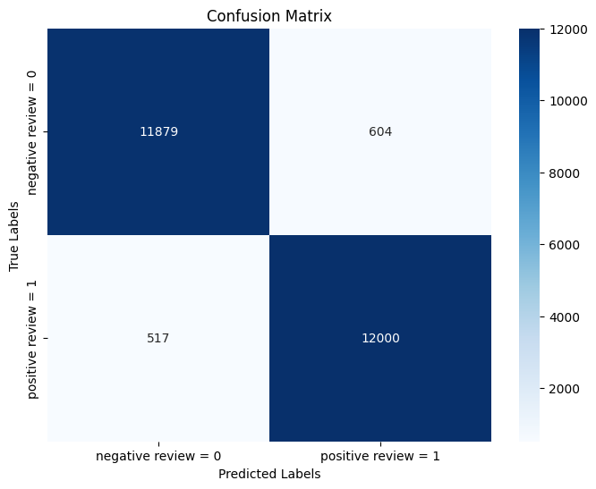

```
Number of mislabeled reviews: 1121
Number of predictions: 25000
Overall accuracy: 95.52 percent
```

```python
###########################################################################################
# PLOT CONFUSION MATRIX ###################################################################
###########################################################################################

# Plot the confusion matrix
plt.figure(figsize=(8, 6))
classes = ['negative review = 0','positive review = 1']
sns.heatmap(cm, annot=True, fmt='d', cmap='Blues', xticklabels=classes, yticklabels=classes)
plt.xlabel('Predicted Labels')
plt.ylabel('True Labels')
plt.title('Confusion Matrix')
plt.show();

misclassified_indices = np.where(test_labels != flattened_binary_predictions)[0];
print("Number of mislabeled reviews:", len(misclassified_indices));
print("Number of predictions:", len(predicted_labels));
print("Overall accuracy:", round((1- (len(misclassified_indices)/len(predicted_labels)))*100, 2), "percent" );
```

```python
###########################################################################################
# SHOW SAMPLE OF MISCLASSIFIED REVIEWS ####################################################
###########################################################################################

# Display some of the misclassified sentiment reviews
misclassified_indices = np.where(test_labels != flattened_binary_predictions)[0]
# Sample size limited to 10 reviews
num_misclassified_reviews = min(10, len(misclassified_indices))
print("Number of mislabeled :", len(misclassified_indices),"\n");
print("Misclassified Reviews:\n")
for i in range(num_misclassified_reviews):
    idx = misclassified_indices[i]
    # print("Review:", texts[idx])
    print("Review:", df_original_reviews['review'].values[idx]) # show original pre processed texts
    print("True Label:", test_labels[idx])
    print("Predicted Label:", binary_predictions[idx])
    print()
```

```
Number of mislabeled : 1121

Misclassified Reviews:

Review: film laboured along predictable story lines shallow characters ever seen writer obviously bought playbook write space disaster movie followed play play particular stereotypical use astronauts talking loved ones outer space putting brave show face disaster done time time againMax Q appears wr…
True Label: 0
Predicted Label: [1]

Review: find intriguing Lee Radziwill Jackie Kennedy sister cousin women would encourage Maysles make Big Edie Little Edie subject film certainly could considered skeletons family closet extra features DVD include several contemporary fashion designers crediting ideas oddball women Id say anyone int…
True Label: 0
Predicted Label: [1]

Review: Ye Lou film Purple Butterfly pits secret organization Purple Butterfly Japanese forces war torn Shanghai Ding Hui Zhang Ziyi exlover Hidehiko Itami Toru Nakamura find opposite sides conflict chance meetingI agree reviewer Paris film substitutes convoluted semihistorical conflict plot without…
True Label: 1
Predicted Label: [0]

Review: hearing George Orwell prophetic masterpiece life Im 37 never read book totally confused Ive seenI familiar concepts covered novel im sure hearsay quotes Without limited knowledge film would complete mystery even Im still educated story 1984 watched itOn plus sideThe cinematography amazing Hu…
True Label: 1
Predicted Label: [0]

Review: movie well directed almost totally disregarded bookI guess trying 2 save time upside 2 actor played finny cute dialog main characters appeared little gay case book Major parts book chopped outYou lost effect haunting book left lacking severely Also strong language although brief unnecessary …
True Label: 0
Predicted Label: [1]

Review: movie took surprise opening credit sequence features nicely done animation plunged semicheesy production betraying low budget characters typical American teens introduced slowly personal detail usually found movies like time shlitz hits fan know one characters either like hate according dist…
True Label: 1
Predicted Label: [0]

Review: keep rigid historical perspective film actually quite entertaining got action adventure romance one premiere casting matchups era Errol Flynn Olivia de Havilland lead roles evident board picture pass muster purists look one hundred percent accuracy story telling get beyond one need put aside…
True Label: 1
Predicted Label: [0]

Review: film quickly gets major chase scene ever increasing destruction first really bad thing guy hijacking Steven Seagal would beaten pulp Seagal driving probably would ended whole premise movieIt seems like decided make kinds changes movie plot plan enjoy action expect coherent plot Turn sense lo…
True Label: 1
Predicted Label: [0]

Review: Based Edgar Rice Burroughs novel EARTHS CORE provides little means escape give brain rest Victorian scientist Dr Abner PerryPeter Cushinginvents giant burrowing machine American partnerDoug McClureuse corkscrew way deep earth explore mysteries may hold soon discover lost world subhuman creat…
True Label: 0
Predicted Label: [1]

Review: read review Alex Sander sic rather looking rating 6 select choice ignorant viewing public would seen desecration Alien fantastic dramatic well made horror/scifi Predator great scifi/action messabout really blame though saw Alien versus Predator average grading 6 stars connoisseurs film frequ…
True Label: 1
Predicted Label: [0]
```